# Bayes_Bahubali_CaseStudy

Thomas Bayes (1701 — 1761) was an English theologian and mathematician that belonged to the Royal Society (the oldest national scientific society in the world and the leading national organisation for the promotion of scientific research in Britain), where other eminent individuals have enrolled, like Newton, Darwin or Faraday. He developed one of the most important theorems of probability, which coined his name: Bayes’ Theorem, or the Theorem of Conditional Probability.

[figure not shown]

H - Hypothesis : Babubali is a great warrior (Existing belief) (Prior Belief)  
E - Event/Evidence : Bahubali winnning the battle against enemy  
P(H) - Probability of Babubali is a great warrior that is already known  
P(E) - Probability of Babubali winning the battle against enemy  
P(H|E) - Probalility of Babubali is a great warrior given that Babubali wins the battle. This means the new probability of Bahubali being a great warrior after observing an event or evidence. (New Belief) (Posterior Belief)  
P(E|H) - Probability of Babubali winning the battle against enemy given that Bahubali is a great warrior

P(E) = P(H) P(E|H) + P(~H) P(E|~H)  
P(E) is the complete Probability of Babubali winning the battle against enemy, no matter whether Bahubali is great warrior or not. It might be possible that Bahubali wins the battle by luck.

```python
import pandas as pd
import numpy as np
```

# Battle with Bandits

[figure not shown]

```python
P_H = 0.001 # Begins with assumption
P_Not_H = 1 - P_H
P_E_given_H = 0.90 # assumption
P_E_given_Not_H = 1 - P_E_given_H
```

```python
P_E = P_H * P_E_given_H + P_Not_H * P_E_given_Not_H
print(P_E)
```

```
0.10079999999999997
```

```python
P_H_given_E = (P_E_given_H * P_H) / P_E
print('Old Belief that Babubali is a great warrior ', P_H )
print('New Belief that Babubali is a great warrior after winning the battle ', P_H_given_E )
```

```
Old Belief that Babubali is a great warrior  0.001
New Belief that Babubali is a great warrior after winning the battle  0.008928571428571432
```

# Battle with Kalkeya

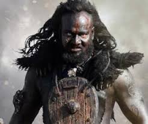

```python
P_H = P_H_given_E
P_Not_H = 1 - P_H
P_E_given_H = 0.90
P_E_given_Not_H = 1 - P_E_given_H
```

```python
P_E = P_H * P_E_given_H + P_Not_H * P_E_given_Not_H
print(P_E)
```

```
0.10714285714285712
```

```python
P_H_given_E = (P_E_given_H * P_H) / P_E
print('Old Belief that Babubali is a great warrior ', P_H )
print('New Belief that Babubali is a great warrior after winning the battle ', P_H_given_E )
```

```
Old Belief that Babubali is a great warrior  0.008928571428571432
New Belief that Babubali is a great warrior after winning the battle  0.07500000000000004
```

# Battle with Bhallaldev

[figure not shown]

```python
P_H = P_H_given_E
P_Not_H = 1 - P_H
P_E_given_H = 0.90
P_E_given_Not_H = 1 - P_E_given_H
```

```python
P_E = P_H * P_E_given_H + P_Not_H * P_E_given_Not_H
print(P_E)
```

```
0.16
```

```python
P_H_given_E = (P_E_given_H * P_H) / P_E
print('Old Belief that Babubali is a great warrior ', P_H )
print('New Belief that Babubali is a great warrior after winning the battle ', P_H_given_E )
```

```
Old Belief that Babubali is a great warrior  0.07500000000000004
New Belief that Babubali is a great warrior after winning the battle  0.42187500000000017
```

# Conclusion

Thus with every battle that Bahubali wins, the core belief or the probalility that Bahubali is a great warrior increases.